# Practical 2: One way and Two way ANOVA

Dr. Jos Hageman  
Mathematical & Statistical Methods group – Biometris  
Wageningen University & Research

jos.hageman@wur.nl

### Packages

In this practical we are using 2 packages, (the package `emmeans`). The R-code below recognizes if certain packages are missing from your package library and, if so, will install them automatically.

```r
# Get overview of all packages on your computer
pkgs <- rownames(installed.packages())

#if our package is missing, install it
if(!"emmeans" %in% pkgs) install.packages("emmeans")

#if our package is missing, install it
if(!"multcomp" %in% pkgs) install.packages("multcomp")
```

## Exercises

### Exercise 1: Taste of tomatoes, One way ANOVA

The taste of three types of tomatoes (round, beef and cherry tomatoes) is compared. Each of 12 tomatoes (four from each type) was judged for taste on a scale from 0 to 100 by a taste panel.

First we’ll introduce the taste data into R and we’ll create a qualitative variable to indicate which tomato type each observation came from. Next we’ll use One way ANOVA to see if there are significant differences in taste between the tomato types.

```r
# taste of three types of tomato: round, beef, or cherry
taste <- c(25.44462, 28.09772, 46.46490, 36.95795, 24.83477, 28.46805,
           48.14579, 31.77559, 53.42217, 70.86571, 57.07008, 38.08433)

#create a qualitative variable indicating tomato type
tomtype <- as.factor(c(rep("round",4), rep("beef",4), rep("cherry",4)))

# one-way ANOVA model
Tastemodel <- lm(taste ~ tomtype)
anova(Tastemodel)
```

```
Analysis of Variance Table

Response: taste
          Df Sum Sq Mean Sq F value  Pr(>F)
tomtype    2 1187.5  593.75  4.7114 0.03981 *
Residuals  9 1134.2  126.02
---
Signif. codes:  0 '***' 0.001 '**' 0.01 '*' 0.05 '.' 0.1 ' ' 1
```

1. Give the total Sum of Squares, Sum of squares for the model and the sum of squares for the residuals.
2. Explain the degrees of freedom for these sum of squares.
3. Test using the information from the ANOVA table if there is a significant difference in taste between the 3 tomato types.
1. The sum of squares for the model (SSM) is 1187.5. The sum of squares for the residuals (SSE) is 1134.2. The TSS (not giving in a standard ANOVA table in R) is SSM + SSE = 1187.5 + 1134.2 = 2321.7.
2. There are 3 tomato types, so the df for tomato type is 3 - 1 = 2. The degrees of freedom for the SSE is n - dfSSE - dfSST = 12 -2 -1 = 9.
3. *H*<sub>0</sub> : *τ*<sub>1</sub> = *τ*<sub>2</sub> = *τ*<sub>3</sub> = 0, versus at least one *τ*<sub>*i*</sub> is different from zero. Under *H*<sub>0</sub> F follows an F-distribution, df1 = 2, df2 = 11 – 2 = 9. Large values of F lead to rejection. P-value is 0.0398 (area to the right of outcome 4.7114) and below 0.05. So, F = 4.7114 is an unlikely outcome when *H*<sub>0</sub> is true. *H*<sub>0</sub> is rejected: it is shown that at least two of the types of tomato have different population means for taste (different expected taste).

Suppose that you had forgotten to introduce factor ‘Tomtype’ and you had used variable ‘type’ instead. In this variable the type have values 1,2 and 3. R will think that tomtype is a quantitative variable and that type 2 is twice as much as type 1.

```r
# this is what happens when you do not introduce
# type of tomato as a factor
# type of tomato: 1 = round, 2 = beef, 3 = cherry tomato)
type <- c(1, 1, 1, 1, 2, 2, 2, 2, 3, 3, 3 ,3)
WrongModel <- lm(taste ~ type)
summary(WrongModel)
```

```
Call:
lm(formula = taste ~ type)

Residuals:
     Min       1Q   Median       3Q      Max
-15.9679  -9.8539  -0.0427   6.6845  19.7534

Coefficients:
            Estimate Std. Error t value Pr(>|t|)
(Intercept)   20.183      9.265   2.179   0.0544 .
type          10.310      4.289   2.404   0.0371 *
---
Signif. codes:  0 '***' 0.001 '**' 0.01 '*' 0.05 '.' 0.1 ' ' 1

Residual standard error: 12.13 on 10 degrees of freedom
Multiple R-squared:  0.3662,    Adjusted R-squared:  0.3029
F-statistic: 5.779 on 1 and 10 DF,  p-value: 0.03707
```

4. Explain why this approach would be very wrong.
4. It will perform simple regression, say: *t**a**s**t**e* = *β*<sub>0</sub> + *β*<sub>1</sub> * *t**y**p**e* + *ϵ*, and the population means *μ*<sub>1</sub>, *m**u*<sub>2</sub>, *μ*<sub>3</sub> will be represented by: *β*<sub>0</sub> + *b**e**t**a*<sub>1</sub>, *b**e**t**a*<sub>0</sub> + 2*b**e**t**a*<sub>1</sub>, *b**e**t**a*<sub>0</sub> + 3*b**e**t**a*<sub>1</sub>. This imposes some severe restrictions, e.g. the difference between tomato types 2 and 1 and between tomato types 3 and 2 are the same: both *b**e**t**a*<sub>1</sub>. By contrast, in the one-way ANOVA model, there are no restrictions upon the population means *μ*<sub>1</sub>, *μ*<sub>2</sub>, *μ*<sub>3</sub> at all.

Next, we ask for the parameter estimates for the one way ANOVA model.

```r
# more output with the one-way anova model
summary(Tastemodel)
```

```
Call:
lm(formula = taste ~ tomtype)

Residuals:
    Min      1Q  Median      3Q     Max
-16.776  -6.726  -1.484   5.093  16.005

Coefficients:
              Estimate Std. Error t value Pr(>|t|)
(Intercept)    33.3061     5.6130   5.934  0.00022 ***
tomtypecherry  21.5545     7.9380   2.715  0.02379 *
tomtyperound    0.9352     7.9380   0.118  0.90880
---
Signif. codes:  0 '***' 0.001 '**' 0.01 '*' 0.05 '.' 0.1 ' ' 1

Residual standard error: 11.23 on 9 degrees of freedom
Multiple R-squared:  0.5115,    Adjusted R-squared:  0.4029
F-statistic: 4.711 on 2 and 9 DF,  p-value: 0.03981
```

5. What is the reference in the model? How can you tell?
6. What is the expected sweet taste for the reference?
7. Explain the estimates for tomtypecherry and tomtyperound in the summary output. What do these values indicate? What are the expected sweet tastes for all 3 types?
5. The reference is tomato type beef, as change from the reference for types cherry and round are given in the coefficients. The means type beef is the reference.
6. The expected sweet taste for beef is equal to the intercept in the coefficients table: 33.3061
7. The estimate for tomtypecherry and tomtyperound are the differences in expected sweet taste from the reference tomato type beef for cherrie and round tomatoes respectively. This makes that the expected sweet taste for beef is equal to the intercept (see questions 5): 33.3061. For cherrie tomatoes this is 33.3061 + 21.5545 = 54.8606 and for round tomatoes this is 33.3061 + 0.9352 = 34.2413

Now, we focus upon the three pairwise comparisons between the types of tomato. We want the experimentwise error rate not to exceed 0.05.

```r
library(multcomp)
# All three pairwise comparisons with Tukeys method
Tukey <- glht(Tastemodel, linfct=mcp(tomtype="Tukey"))
summary(Tukey)
```

```
     Simultaneous Tests for General Linear Hypotheses

Multiple Comparisons of Means: Tukey Contrasts


Fit: lm(formula = taste ~ tomtype)

Linear Hypotheses:
                    Estimate Std. Error t value Pr(>|t|)
cherry - beef == 0   21.5545     7.9380   2.715   0.0563 .
round - beef == 0     0.9352     7.9380   0.118   0.9924
round - cherry == 0 -20.6193     7.9380  -2.598   0.0680 .
---
Signif. codes:  0 '***' 0.001 '**' 0.01 '*' 0.05 '.' 0.1 ' ' 1
(Adjusted p values reported -- single-step method)
```

8. Why would you use Tukey’s method rather than Fisher’s LSD?
9. Study the output for the pairwise comparisons. What do you conclude?
8. Using the scheme from the lecture notes, We would like the experimentwise error rate to be below some threshold, and we also we want to compare a number of treatments all pairwise. This leads us to Tukey’s method.
9. With experimentwise error rate α=0.05, the conclusion is that none of the three null hypotheses is rejected. It cannot be shown that there are differences in expected taste among the three tomato types.

Unlike some other software, in R, it is quite easy to switch to a different reference group. The followed R code used the cherry tomatoes as reference and compares the new summary output with the previous output.

```r
tomtype2 <- relevel(tomtype, ref="cherry")
Tastemodel2 <- lm(taste ~ tomtype2)
summary(Tastemodel)
```

```
Call:
lm(formula = taste ~ tomtype)

Residuals:
    Min      1Q  Median      3Q     Max
-16.776  -6.726  -1.484   5.093  16.005

Coefficients:
              Estimate Std. Error t value Pr(>|t|)
(Intercept)    33.3061     5.6130   5.934  0.00022 ***
tomtypecherry  21.5545     7.9380   2.715  0.02379 *
tomtyperound    0.9352     7.9380   0.118  0.90880
---
Signif. codes:  0 '***' 0.001 '**' 0.01 '*' 0.05 '.' 0.1 ' ' 1

Residual standard error: 11.23 on 9 degrees of freedom
Multiple R-squared:  0.5115,    Adjusted R-squared:  0.4029
F-statistic: 4.711 on 2 and 9 DF,  p-value: 0.03981
```

```r
summary(Tastemodel2)
```

```
Call:
lm(formula = taste ~ tomtype2)

Residuals:
    Min      1Q  Median      3Q     Max
-16.776  -6.726  -1.484   5.093  16.005

Coefficients:
              Estimate Std. Error t value Pr(>|t|)
(Intercept)     54.861      5.613   9.774 4.33e-06 ***
tomtype2beef   -21.555      7.938  -2.715   0.0238 *
tomtype2round  -20.619      7.938  -2.598   0.0289 *
---
Signif. codes:  0 '***' 0.001 '**' 0.01 '*' 0.05 '.' 0.1 ' ' 1

Residual standard error: 11.23 on 9 degrees of freedom
Multiple R-squared:  0.5115,    Adjusted R-squared:  0.4029
F-statistic: 4.711 on 2 and 9 DF,  p-value: 0.03981
```

10. What has changed in the new summary output compared to the old one?
11. Recalculate the expected sweet tastes for the 3 tomate types and compare them with the values calculated for question 7.
10. What has changed is the reference type. For the new output it is the cherry tomatoes so intercept corresponds with the expected sweet taste for cherries. The other 2 estimates give the change from cherry tomatoes to beef and round. The old output had beef as reference and gave the change in expected taste for cherry and round.
11. The expected sweet taste for cherries is 54.861. For beef tomatoes the change in expected taste is given compared to the reference, so the expected sweet taste for beef tomatoes is 54.861 - 21.555 = 33.306. Likewise, the expected sweet taste for round is calculated as: 54.861 - 20.619 = 34.242. Rounding differences can occur.

### Exercise 2: Pesticides and fruit

In an experiment the effect of four pesticides upon the yield of fruit is studied for three varieties of citrus trees. The four pesticides were randomly assigned to eight trees of each variety, with two trees per pesticide, per variety. This is example 14.6, page 896 [816] in O&L. We are going to analyse the data with a two-way analysis of variance model with main effects and interactions for pesticides and varieties. The model can be denoted as: *E*(*y*<sub>*i**j**k*</sub>) = *μ* + *τ*<sub>*i*</sub> + *β*<sub>*j*</sub> + *τ**β*<sub>*i**j*</sub> + *ϵ*<sub>*i**j**k*</sub>, with *τ*<sub>*i*</sub> for the i-th pesticide, *β*<sub>*j*</sub> for the j-th variety, *τ**β*<sub>*i**j*</sub> for interaction, and index *k* for replicates of combinations of pesticide and variety (the 12 treatments), i = 1, 2, 3, 4; j = 1, 2, 3; k = 1, 2.

We will start by introducing the data and constructing profile plots to get the data a little better.

```r
# response is yield of fruit y,
# comparing four pesticides or three varieties f fruit trees
# eight trees of each variety randomly assigned to the four pesticides
# two trees per variety, per pesticide
y <- c(49, 39, 55, 41, 66, 68, 50, 55, 67, 58, 85, 92, 43, 38, 53, 42, 69, 62, 53, 48, 85, 73, 85, 99)
pesticide <- factor(c(1,  1,  1,  1,  1, 1, 2, 2, 2, 2, 2, 2, 3, 3, 3, 3, 3, 3, 4, 4, 4, 4, 4, 4))
variety <- factor(c(1, 1, 2, 2, 3, 3, 1, 1, 2, 2, 3, 3, 1, 1, 2, 2, 3, 3, 1, 1, 2, 2, 3, 3))

# printing the data
print(cbind(y, variety, pesticide))
```

```
       y variety pesticide
 [1,] 49       1         1
 [2,] 39       1         1
 [3,] 55       2         1
 [4,] 41       2         1
 [5,] 66       3         1
 [6,] 68       3         1
 [7,] 50       1         2
 [8,] 55       1         2
 [9,] 67       2         2
[10,] 58       2         2
[11,] 85       3         2
[12,] 92       3         2
[13,] 43       1         3
[14,] 38       1         3
[15,] 53       2         3
[16,] 42       2         3
[17,] 69       3         3
[18,] 62       3         3
[19,] 53       1         4
[20,] 48       1         4
[21,] 85       2         4
[22,] 73       2         4
[23,] 85       3         4
[24,] 99       3         4
```

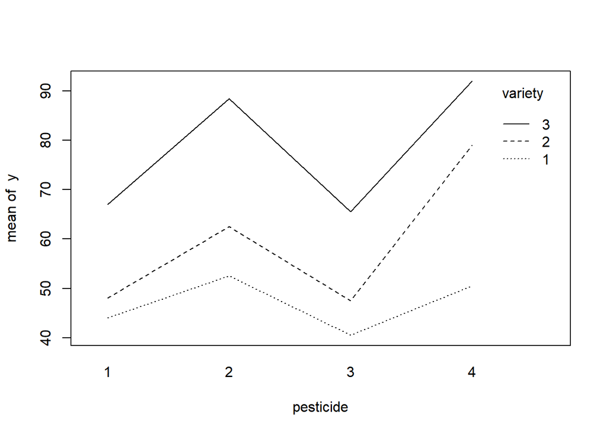

```r
#profile plot
interaction.plot(pesticide, variety, y)
```

1. What is your impression about the possible presence of interaction, looking at this plot?
2. What happens if you switch ‘pesticide’ and ‘variety’ in routine ‘interaction.plot’ and run this line again?
1. The lines in the plot are roughly parallel which may indicate that perhaps interaction can be ignored.
2. In the plot with variety on the x-axis, the broken line for Pesticide 4 seems ‘less parallel’ compared to the broken lies for the other pesticides. But if you look carefully you can see the same thing in the plot first plot: the combination of pesticide 4 and variety 2 is a bit ‘off’. The eye is easily misled.

Next we will run the two-way ANOVA model, and ask for the summary. The interaction model is just a complex way to represent the 12 separate means of the combinations of varieties and pesticides.

```r
# a two-way analysis of variance with interaction
twowayint <- lm(y ~ variety + pesticide + variety:pesticide)
anova(twowayint)
```

```
Analysis of Variance Table

Response: y
                  Df Sum Sq Mean Sq F value    Pr(>F)
variety            2 3996.1 1998.04 47.2443 2.048e-06 ***
pesticide          3 2227.5  742.49 17.5563 0.0001098 ***
variety:pesticide  6  456.9   76.15  1.8007 0.1816844
Residuals         12  507.5   42.29
---
Signif. codes:  0 '***' 0.001 '**' 0.01 '*' 0.05 '.' 0.1 ' ' 1
```

```r
summary(twowayint)
```

```
Call:
lm(formula = y ~ variety + pesticide + variety:pesticide)

Residuals:
   Min     1Q Median     3Q    Max
 -7.00  -3.75   0.00   3.75   7.00

Coefficients:
                    Estimate Std. Error t value Pr(>|t|)
(Intercept)           44.000      4.598   9.568 5.76e-07 ***
variety2               4.000      6.503   0.615   0.5500
variety3              23.000      6.503   3.537   0.0041 **
pesticide2             8.500      6.503   1.307   0.2157
pesticide3            -3.500      6.503  -0.538   0.6003
pesticide4             6.500      6.503   1.000   0.3373
variety2:pesticide2    6.000      9.197   0.652   0.5264
variety3:pesticide2   13.000      9.197   1.414   0.1829
variety2:pesticide3    3.000      9.197   0.326   0.7499
variety3:pesticide3    2.000      9.197   0.217   0.8315
variety2:pesticide4   24.500      9.197   2.664   0.0206 *
variety3:pesticide4   18.500      9.197   2.012   0.0673 .
---
Signif. codes:  0 '***' 0.001 '**' 0.01 '*' 0.05 '.' 0.1 ' ' 1

Residual standard error: 6.503 on 12 degrees of freedom
Multiple R-squared:  0.9294,    Adjusted R-squared:  0.8647
F-statistic: 14.36 on 11 and 12 DF,  p-value: 2.955e-05
```

We are going to compare the pesticides averaged over the varieties. First, verify that the test for main effects of factor pesticides is significant (α=0.05). Next, there are a number of different routes that can be followed in R to make the pairwise comparisons. First, we are going to look at features from a library called ‘emmeans’.

```r
library(emmeans)
#comparing pesticides averaged over varieties
marginal <- emmeans(twowayint, ~ pesticide)
```

```
NOTE: Results may be misleading due to involvement in interactions
```

```r
# Fisher's LSD method
pairs(marginal, adjust="None")
```

```
 contrast                estimate   SE df t.ratio p.value
 pesticide1 - pesticide2   -14.83 3.75 12  -3.951  0.0019
 pesticide1 - pesticide3     1.83 3.75 12   0.488  0.6341
 pesticide1 - pesticide4   -20.83 3.75 12  -5.549  0.0001
 pesticide2 - pesticide3    16.67 3.75 12   4.439  0.0008
 pesticide2 - pesticide4    -6.00 3.75 12  -1.598  0.1360
 pesticide3 - pesticide4   -22.67 3.75 12  -6.037  0.0001

Results are averaged over the levels of: variety
```

9. There is a warning error about interactions. Is this a problem?
10. Why do you think that Fisher’s LSD method is indicated by adjust=”None”?
11. How many pairwise comparisons do you think we are going to need?
9. The output starts with a warning: ‘NOTE: Results may be misleading due to involvement in interactions’. Since we have just seen that interaction is not significant we can ignore this warning.
10. The adjust=“None” tells R that no adjustment is required for control of experimentwise error rate, i.e. we get Fisher’s LSD method.
11. There are four different pesticides, so there are six pairwise comparisons. Of these, two are not significant (1 versus 3 and 2 versus 4); the other four differences: 1 versus 2, 1 versus 4, 2 versus 3, and 3 versus 4, are significant.

Next, we will produce pairwise comparisons with Tukey’s method with experimentwise error rate not exceeding 0.05.

```r
# Tukey's method
pairs(marginal, adjust="Tukey")
```

```
 contrast                estimate   SE df t.ratio p.value
 pesticide1 - pesticide2   -14.83 3.75 12  -3.951  0.0090
 pesticide1 - pesticide3     1.83 3.75 12   0.488  0.9602
 pesticide1 - pesticide4   -20.83 3.75 12  -5.549  0.0006
 pesticide2 - pesticide3    16.67 3.75 12   4.439  0.0039
 pesticide2 - pesticide4    -6.00 3.75 12  -1.598  0.4155
 pesticide3 - pesticide4   -22.67 3.75 12  -6.037  0.0003

Results are averaged over the levels of: variety
P value adjustment: tukey method for comparing a family of 4 estimates
```

12. With which method, Fisher’s or Tukey’s, do you expect to find higher P-values?
13. Compare the P-values of the two methods to see whether you were right in your expectations. So, which method is more severe, Fisher’s or Tukey’s method?
14. Does this influence the conclusions?
12. Tukey’s method for pairwise comparisons involves protection of experimentwise error rate. Therefore it is more severe than Fisher’s method, i.e. a difference within a pair needs to be larger to be significant. Hence, we expect to see larger P-values in the output below.
13. Indeed, all P-values with Tukey’s method are larger than the P-values found with Fisher’s LSD.
14. The conclusions remain the same in this case.

Note that you should decide in advance whether you want to use Fisher’s or Tukey’s method. In practice you should not look at both and then decide which one to use.